# Idiographic Memory Modelling in ACT-R using Alternating Maximum Likelihood Estimation

Maarten van der Velde

Last updated: 2026-06-03

```r
library(here)
library(data.table)
library(janitor)
library(ggplot2)
library(purrr)
library(furrr)
library(tidyr)
library(jsonlite)
library(patchwork)
library(ggExtra)
library(png)
library(grid)

# Set up parallel processing
plan(multisession, workers = 8)

source(here("scripts", "actr-functions.R"))

# Define colours
col_blue <- "#0571b0"
col_red <- "#ca0020"
col_green <- "#1b9e77"
```

# ACT-R memory model

The ACT-R memory model describes retrieval performance using a set of equations, which involve the following parameters:

- $\alpha$: Speed of Forgetting
- $\tau$: Retrieval threshold
- $s$: Activation noise
- $F$: Latency factor
- $t_{er}$: Non-retrieval time

The memory model can be made to fit an individual’s data, and predict their future performance, by adjusting one or more of these parameters.

# Activation function

The activation of a memory chunk $x$ with previous encounters at $t_0$, $\ldots$, $t_n$ seconds ago, is given by the following equation:

$$A_x(t) = \ln\left(\sum_{j=0}^{n}
t_j^{-d_x(t)} \right)$$
where the decay of each new trace is determined in part by the activation immediately prior to the moment of its creation (this activation in the time step preceding the creation of the new trace is indicated by $A_x(t_{n-1})$), scaled by a constant ($c$), and in part by a chunk-specific offset in decay ($\alpha_x$), which we call the Speed of Forgetting:

$$d_x(t) = ce^{A_x(t_{n-1})} +
\alpha_x$$
For example, the activation over time of a chunk with encounters at 0, 10 and 60 seconds (with default parameter settings) looks as follows, where each encounter adds a new decaying trace:

```r
t <- seq(0, 100, 0.1)
traces <- c(0, 10, 60)
plot(t, sapply(t, function(t) calculate_activation_memory(t, traces[1], .3)), type = "l", lwd = .5, xlab = "Time (s)", ylab = "Activation")
lines(t, sapply(t, function(t) calculate_activation_memory(t, traces[1:2], .3)), type = "l", lwd = .5)
```

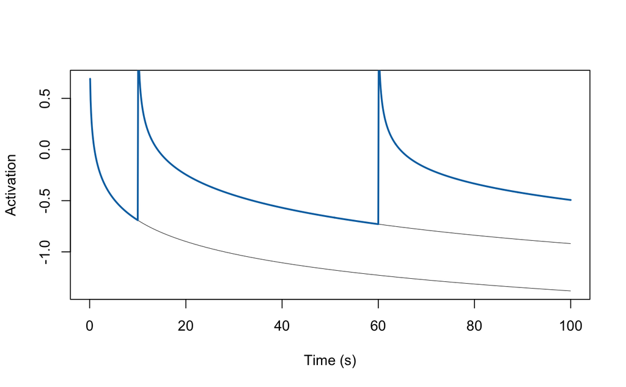

```r
lines(t, sapply(t, function(t) calculate_activation_memory(t, traces, .3)), type = "l", col = col_blue, lwd = 2)
```

# Likelihood functions

## Response accuracy

The likelihood of observing a correct response $c$ given the activation $A$, retrieval threshold $\tau$, and activation noise $s$ is given by the logistic function that ACT-R uses to calculate the probability of retrieval:

$$L(A, \tau, s | c) = p(c | A, \tau, s) =
\frac{1}{(1 + e^{\frac{-(A - \tau)}{s}})}$$
For example, if we assume a retrieval threshold of -0.8 and an activation noise of 0.3, the probability of a correct response as a function of activation looks as follows, where $p(c) = 0.5$ when $A = \tau$, and where the steepness of the curve is modulated by the amount of noise:

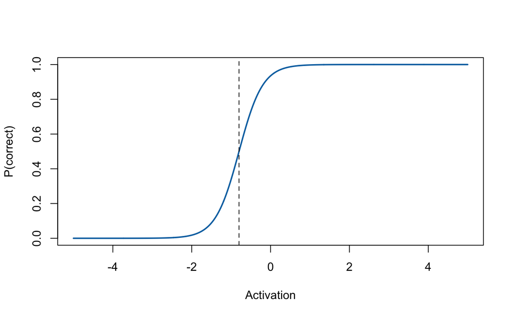

```r
a <- seq(-5, 5, 0.01)
plot(a, correct_likelihood(a, tau = -.8, s = .3), type = "l", col = col_blue, lwd = 2, xlab = "Activation", ylab = "P(correct)")
abline(v = -0.8, col = "black", lty = 2)
```

## Response time

The likelihood function for response times is given by the probability density function of the LogLogistic distribution:
$$L(F, A, s, t_{er} | RT) = p(RT | F, A, s, t_{er})
= \frac{(\beta/\alpha)((RT - t_{er})/\alpha)^{\beta - 1}}{(1 + ((RT -
t_{er})/\alpha)^\beta)^2}$$
Where:
$$\alpha = F*e^{-A}$$
$$\beta = \frac{1}{s}$$

The figure below shows a few examples of the likelihood function for response times, given different parameter settings.

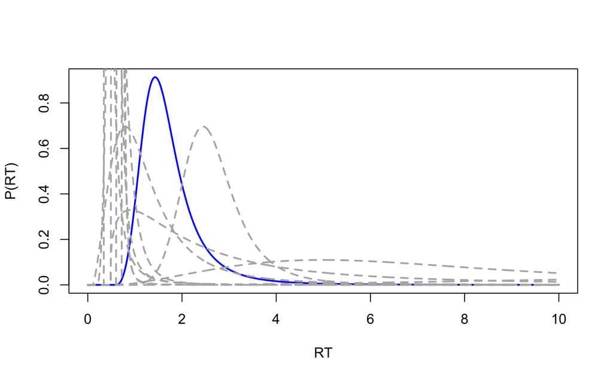

```r
rt <- seq(0, 10, 0.01)
plot(rt, rt_likelihood(rt, a = 0, s = .3, lf = 1, t0 = .6), type = "l", col = "blue", lwd = 2, xlab = "RT", ylab = "P(RT)")
set.seed(0)
a_values <- rnorm(10, 0, 2)
s_values <- runif(10, 0.2, 0.8)
lf_values <- runif(10, 1, 1)
t0_values <- runif(10, 0, 1)
for (i in 1:10) {
  lines(rt, rt_likelihood(rt, a = a_values[i], s = s_values[i], lf = lf_values[i], t0 = t0_values[i]), col = "grey70", lwd = 2, lty = 2)
}
```

# How do parameters map onto behaviour?

To get a better feeling for the effect that changing each parameter has on the accuracy and RT distributions, we’ll calculate some examples with different parameter values, assuming a few previous trials. Incorrect responses are visualised as negative response times.

```r
param_setting_examples <- list(
  alpha = c(.1, .2, .3, .4, .5),
  tau = c(-2, -1, 0, 1, 2),
  s = c(.01, .05, .1, .15, .2),
  lf = c(.25, .5, 1, 1.5, 2),
  ter = c(.25, .5, .75, 1, 1.25)
)

param_default <- list(
  alpha = .3,
  tau = 0,
  s = .1,
  lf = 1,
  ter = .75
)

make_varying_param <- function(name, values, defaults) {
  dt <- as.data.table(defaults)
  dt <- dt[rep(1, length(values))]
  dt[, (name) := values]
  dt[, varying := name]
  dt[]
}

param_grid <- rbindlist(list(
  make_varying_param("alpha", param_setting_examples$alpha, param_default),
  make_varying_param("tau",   param_setting_examples$tau,   param_default),
  make_varying_param("s",     param_setting_examples$s,     param_default),
  make_varying_param("lf",    param_setting_examples$lf,    param_default),
  make_varying_param("ter",   param_setting_examples$ter,   param_default)
))

# Calculate activation, assuming previous encounters
param_grid[, activation := calculate_activation_memory(t = 60, traces = c(0, 10, 20, 30, 40, 50), sof = alpha), by = .I]

# Sample responses
n_responses <- 1e6

sample_correct <- function(n = 1, a, tau, s) {
  p_correct <- correct_likelihood(a, tau, s)
  correct <- rbinom(n, 1, p_correct)
  return (as.logical(correct))
}

sample_rt <- function (n = 1, a, s, lf, ter) {
  alpha <- exp(-a) * lf
  beta <- sqrt(3) / (pi * s)
  u <- runif(n)
  rt <- alpha * (u / (1 - u))^(1 / beta) + ter
  return (rt)
}

sample_response <- function (n = 1, a, tau, s, lf, ter) {
  correct <- sample_correct(n, a, tau, s)
  rt <- sample_rt(n, a = fifelse(correct, a, tau), s, lf, ter)
  return (data.table(
    correct = correct,
    rt = rt
  ))
}

sim_data <- param_grid[, sample_response(
  n   = n_responses,
  a   = activation,
  tau = tau,
  s   = s,
  lf  = lf,
  ter = ter
), by = .(alpha, tau, s, lf, ter, varying)]

sim_data[, value := fcase(
  varying == "alpha", alpha,
  varying == "tau",   tau,
  varying == "s",     s,
  varying == "lf",    lf,
  varying == "ter",   ter
)]
```

```r
param_titles <- list(
  alpha = "Speed of Forgetting",
  tau   = "Retrieval threshold",
  s     = "Activation noise",
  lf    = "Latency factor",
  ter   = "Non-retrieval time"
)

param_symbols <- list(
  alpha = "alpha",
  tau   = "tau",
  s     = "s",
  lf    = "F",
  ter   = "t[er]"
)

rt_density_plot <- function(dt, param_name) {

  # Flip the sign on error RTs
  dt_plot <- copy(dt)
  dt_plot[, rt := fifelse(correct, rt, -rt)]

  # Create labels like "α = 0.1", "α = 0.2"
  vals <- sort(unique(dt_plot[varying == param_name]$value))
  # Create factor with expression-level legend labels
  dt_plot[, value_factor := factor(value, levels = vals)]
  levels(dt_plot$value_factor) <- sapply(
    vals,
    function(v) parse(text = paste0(param_symbols[[param_name]], " == ", v))
  )

  ggplot(dt_plot[varying == param_name][between(rt, -5, 5)], aes(x = rt, colour = value_factor, fill = value_factor)) +
    geom_vline(xintercept = 0, lty = 2, colour = "grey80") +
    geom_density(colour = NA, alpha = .1, bw = .1) +
    geom_line(stat = "density", linewidth = .8, alpha = .9, bw = .1) +
    labs(title = param_titles[[param_name]],
         colour = NULL,
         fill = NULL,
         x = "Response time (s)",
         y = "Density") +
    scale_x_continuous(limits = c(-5, 5)) +
    scale_colour_manual(values = RColorBrewer::brewer.pal(name = "GnBu", n = 6)[2:6],
                        labels = scales::label_parse()) +
    scale_fill_manual(values = RColorBrewer::brewer.pal(name = "GnBu", n = 6)[2:6],
                        labels = scales::label_parse()) +
    guides(colour = guide_legend(ncol = 1)) +
    theme_bw() +
    theme(legend.position = c(0.01, 0.99),
          legend.justification = c(0, 1),
          legend.spacing.y = unit(0.1, "cm"),
          legend.background = element_rect(fill = alpha("white", 0.7), colour = NA),
          axis.ticks.y = element_blank(),
          axis.text.y = element_blank(),
          panel.grid.major.y = element_blank(),
          panel.grid.minor.y = element_blank())
}

# Also include the model schematic
model_img <- readPNG(here("output", "actr_amle_model.png"))
g <- rasterGrob(model_img, interpolate = TRUE)

model_img_plot <- ggplot() +
  annotation_custom(g, xmin = -Inf, xmax = Inf, ymin = -Inf, ymax = Inf) +
  labs(title = "Model schematic") +
  theme_void() +
  theme(
    plot.title = element_text(hjust = 0, vjust = 2.85)  # vjust >1 moves it higher
  )

param_plots <- lapply(unique(sim_data$varying), function (param) rt_density_plot(sim_data, param))

model_param_plots <- c(list(model_img_plot), param_plots) |>
  wrap_plots(ncol = 3, nrow = 2) +
  plot_annotation(tag_levels = "A")

model_param_plots <- patchwork:::`&.gg`(model_param_plots, theme(plot.tag = element_text(face = "bold", size = 14)))

ggsave(filename = here("output", "model_parameter_effects.png"), plot = model_param_plots, width = 10, height = 6.5)
```

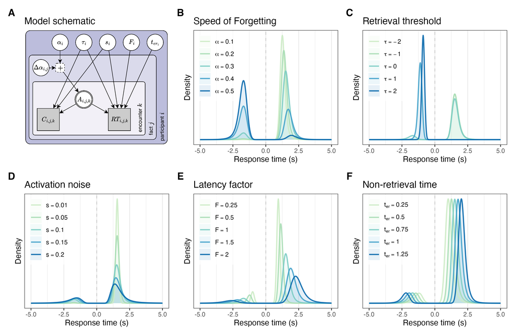

# Combined log-likelihood function

We want to apply this method to data from a memory task in which participants can encounter each fact multiple times, resulting in a sequence of time-stamped observations of accuracy and response time. To find the best fitting parameters, we need a log-likelihood function for such a sequence. This function considers all the trials in a session in which a participant encounters a given fact, and evaluates the likelihood of the participant’s response accuracy and RT given a certain choice of model parameters.

```r
fact_log_likelihood <- function(data, sof, tau, s, lf, ter, includes_study_trial = TRUE) {
  ll <- 0
  # Loop over fact encounters
  start_index <- ifelse(includes_study_trial, 2, 1)
  for (i in start_index:length(data$traces)) {
    # Calculate activation at the time of retrieval
    activation <- calculate_activation_memory(data$traces[i], data$traces[1:(i-1)], sof)

    if (data$correct[i]) {
      ll <- ll + log(max(correct_likelihood(activation, tau, s), 1e-20))
      ll <- ll + log(max(rt_likelihood(data$rt[i], activation, s, lf, ter), 1e-20))
    } else {
      ll <- ll + log(max(1 - correct_likelihood(activation, tau, s), 1e-20))
      ll <- ll + log(max(rt_likelihood(data$rt[i], tau, s, lf, ter), 1e-20))
    }
  }

  return(ll)
}
```

At the session-level, we define a log-likelihood function that sums over all fact sequences in the session.

```r
session_log_likelihood <- function(data, sof, tau, s, lf, ter, includes_study_trials = TRUE) {
  ll <- 0
  for (i in 1:length(data)) {
    ll <- ll + fact_log_likelihood(data[[i]], sof[[i]], tau, s, lf, ter, includes_study_trials)
  }
  return(ll)
}
```